# Analysis of Environmental Data - Lab Exercise #6

Sarah Guitart

Students I worked with: Ian Eggleston

### Q1

*Show the R code you used to define your sse_mean() function.*

```r
{
rm(list = ls())
require(palmerpenguins)
sse_mean = function(x)
{
  return(sd(x, na.rm = TRUE) / sqrt(length(na.omit(x))))
}
}
sse_mean(penguins$body_mass_g)
```

```
[1] 43.36473
```

```r
sse_mean(mtcars$mpg)
```

```
[1] 1.065424
```

### Q2

*Show the code you used to define your two_group_resample_diff() function.*

```r
two_group_resample_diff = function(x, n_1, n_2)
{
 dat_1 = sample(na.omit(x), n_1, replace = TRUE)
 dat_2 = sample(na.omit(x), n_2, replace = TRUE)
 diff_sim = mean(dat_1, na.rm = T) - mean(dat_2, na.rm = T)
   return(diff_sim)
}
```

### Q3

*Does your function perform Monte Carlo or bootstrap resampling, i.e. does it simulate a null or an alternative hypothesis?*

A: Our function performs Monte Carlo resampling, as it simulates a null hypothesis. In this function, the values within the dataset are completely reshuffled.

### Q4

*Create a histogram of the resampled differences of means.*

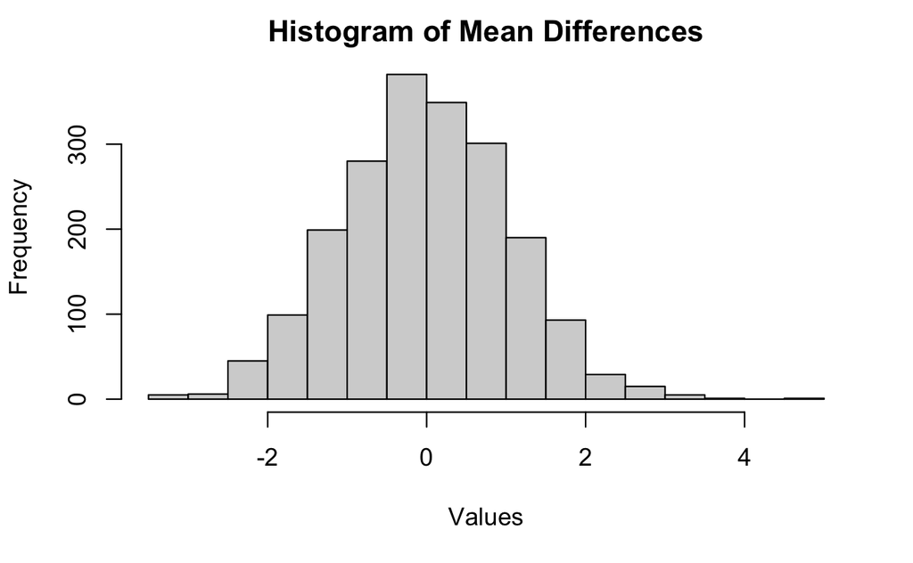

```r
{
dat_pen <- droplevels(subset(penguins, species != "Gentoo"))
n = 2000
mean_differences = c()
for (i in 1:n)
{
  mean_differences = c(
    mean_differences,
    two_group_resample_diff(dat_pen$flipper_length_mm, 68, 152)
  )
}
}
hist(mean_differences, main = "Histogram of Mean Differences",
     xlab = "Values")
```

### Q5

*How many of your resampled differences of means had a magnitude greater than 5.8?*

```r
sum(abs(mean_differences) > 5.8)
```

```
[1] 0
```

### Q6

*Given a p value of less than 1 per 10 million, how many simulations do you think you would have to do to see a difference in mean flipper length equal to or greater than 5.8 mm?*

A: You would need to do over 10 million simulations to see a difference in mean flipper length equal to or greater than 5.8 mm.

### Q7

*Include a boxplot of your chosen variable in your report.*

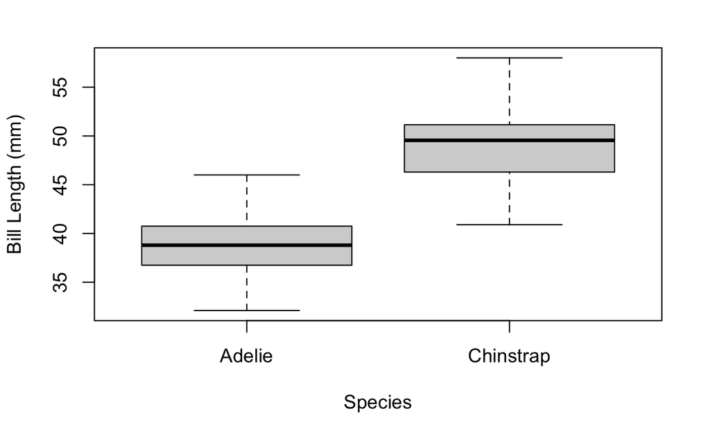

```r
  boxplot(
    bill_length_mm ~ species, data = dat_pen,
    xlab = "Species", ylab = "Bill Length (mm)")
```

### Q8

*Report the group means and difference between the means.*

```r
{
agg_means = aggregate(
  bill_length_mm ~ species,
  data = dat_pen,
  FUN = "mean",
  na.rm = TRUE)
diff_crit <- round(abs(agg_means[1,2] - agg_means[2,2]), digits = 2)
}
agg_means
```

| species | bill_length_mm |
| --- | --- |
| Adelie | 38.79139 |
| Chinstrap | 48.83382 |

```r
diff_crit
```

```
[1] 10.04
```

### Q9

*Interpret the p-value from the t-test output in plain, non-technical English that a non-statistician would understand.*

```r
{
t_test_bill <- t.test(dat_pen$bill_length_mm ~ dat_pen$species)
t_test_bill
}
```

```
    Welch Two Sample t-test

data:  dat_pen$bill_length_mm by dat_pen$species
t = -21.865, df = 106.97, p-value < 2.2e-16
alternative hypothesis: true difference in means between group Adelie and group Chinstrap is not equal to 0
95 percent confidence interval:
 -10.952948  -9.131917
sample estimates:
   mean in group Adelie mean in group Chinstrap
               38.79139                48.83382
```

A: The p-value in a t-test relates to the likelihood of getting a value equal to or greater than the t-value of your sample. As the t-value moves away from zero (either positively or negatively), the average difference between the two groups gets larger. The p-value tells us the likelihood we would get the t-value from our sample if our sample was completely random and there was no difference at all between the two groups. The p-value from our t-test is 2.2 x 10^-16, which is 2.2 with 15 zeros in front of it. This means it is incredibly small and therefore, significant. Because it is such a small value, we know that it would be unlikely to get a t-value of -21.865 if the two groups were completely random. So with this p-value, we can reject our null hypothesis that there is no difference in the average of the two groups.

### Q10

*How many differences in means were greater than diff_crit?*

```r
n = 2000
mean_differences_2 = c()
for (i in 1:n)
{
  mean_differences_2 = c(
    mean_differences_2,
    two_group_resample_diff(dat_pen$bill_length_mm, 68, 152)
  )
}
sum(abs(mean_differences_2) > abs(diff_crit))
```

```
[1] 0
```

### Q11

*Include a histogram of your simulation results in your report. Make sure it has appropriate title and labels.*

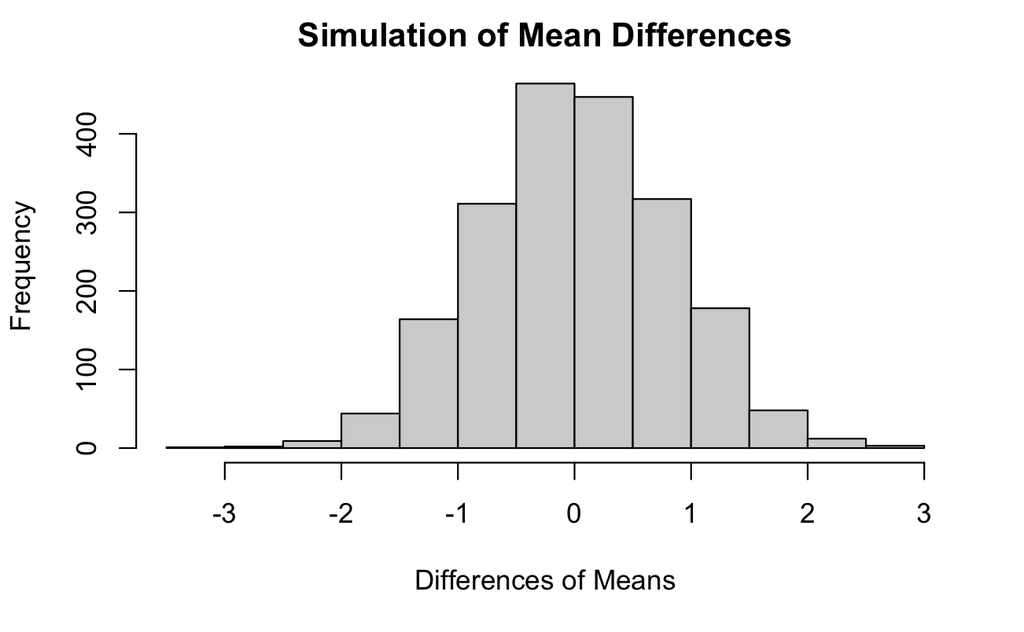

```r
hist(mean_differences_2, main = "Simulation of Mean Differences",
     xlab = "Differences of Means")
```